# Metaphor Analysis in Kickstarter Campaigns

**Sean Trott and Alex Liebscher**

# Introduction

We have several dependent variables which we would like to model as accurately as possible to determine the variables which contribute most to their outcomes. In particular, we care about the effect of the metaphor (or lack thereof) in each project. We first explore the data a little, and then begin a series of model comparisons for the dependent variables. Comparing models gives transparency to the contributions of each variable toward the target.

1. Do projects that use metaphor generally receive better funding? How does using metaphor (and which type of metaphor family) influence campaign success, number of backers, and mean donation?
2. Does higher metaphor productivity change the result?
3. How can we characterize projects by the metaphors they employ?
4. Within a metaphor family, are there canonical instantiations of a metaphor? (E.g. “fight battle”). Or even if productivity is low generally, are instantiations varied?
5. How does metaphor vary with other interesting features, such as project description length, goal amount, project type/category, cancer type, or recipient gender?

# Related Work

Hendricks, R. K., Demjén, Z., Semino, E., & Boroditsky, L. (2018). Emotional Implications of Metaphor: Consequences of Metaphor Framing for Mindset about Cancer. Metaphor and Symbol, 33(4), 267–279. https://doi.org/10.1080/10926488.2018.1549835

Semino, E., Demjén, Z., Demmen, J., Koller, V., Payne, S., Hardie, A., & Rayson, P. (2017). The online use of Violence and Journey metaphors by patients with cancer, as compared with health professionals: a mixed methods study. BMJ Supportive & Palliative Care, 7(1), 60–66. https://doi.org/10.1136/bmjspcare-2014-000785

## Load Data

```r
dat <- read.csv('../../data/processed/gofundme_projects.csv')
head(dat)
```

```
##                                                             url
## 1         https://www.gofundme.com/ofe-vs-stage-4-breast-cancer
## 2 https://www.gofundme.com/please-help-uri-urgent-medical-costs
## 3                              https://www.gofundme.com/mattheu
## 4                         https://www.gofundme.com/wewillbeatnb
## 5    https://www.gofundme.com/8e3gxs-fighting-pancreatic-cancer
## 6     https://www.gofundme.com/housing-for-21-yo-cancer-fighter
##                                                 name   launched month year
## 1                               Rest In Peace Mami ❤️ 2016-10-28    10 2016
## 2 Help Uri beat Cancer & cover urgent medical costs! 2019-01-17     1 2019
## 3                     Mattheu's Fight Against Cancer 2017-12-07    12 2017
## 4                 Help Beat Nb save KIDS with cancer 2016-12-29    12 2016
## 5                Tikey is fighting Pancreatic Cancer 2018-12-15    12 2018
## 6                  Housing for 21 Y/O Cancer Fighter 2018-08-24     8 2018
##   usd_pledged  goal backers mean_donation text_length_words
```

[output cut: 48 more lines]

```r
nrow(dat)
```

```
## [1] 780
```

```r
colnames(dat)
```

```
##  [1] "url"                   "name"
##  [3] "launched"              "month"
##  [5] "year"                  "usd_pledged"
##  [7] "goal"                  "backers"
##  [9] "mean_donation"         "text_length_words"
## [11] "text"                  "id"
## [13] "text_length_sentences" "pledged_to_goal"
## [15] "duration_float"        "day_of_week"
## [17] "from_US"               "cancer_type"
## [19] "status"                "battle_metaphor"
## [21] "journey_metaphor"      "battle_uniques"
## [23] "journey_uniques"       "battle_salience"
## [25] "journey_salience"      "first_instantiation"
## [27] "battle_prod"           "journey_prod"
## [29] "source"
```

```r
library(lme4)
library(tidyverse)
```

# Data Exploration

### Projects per year

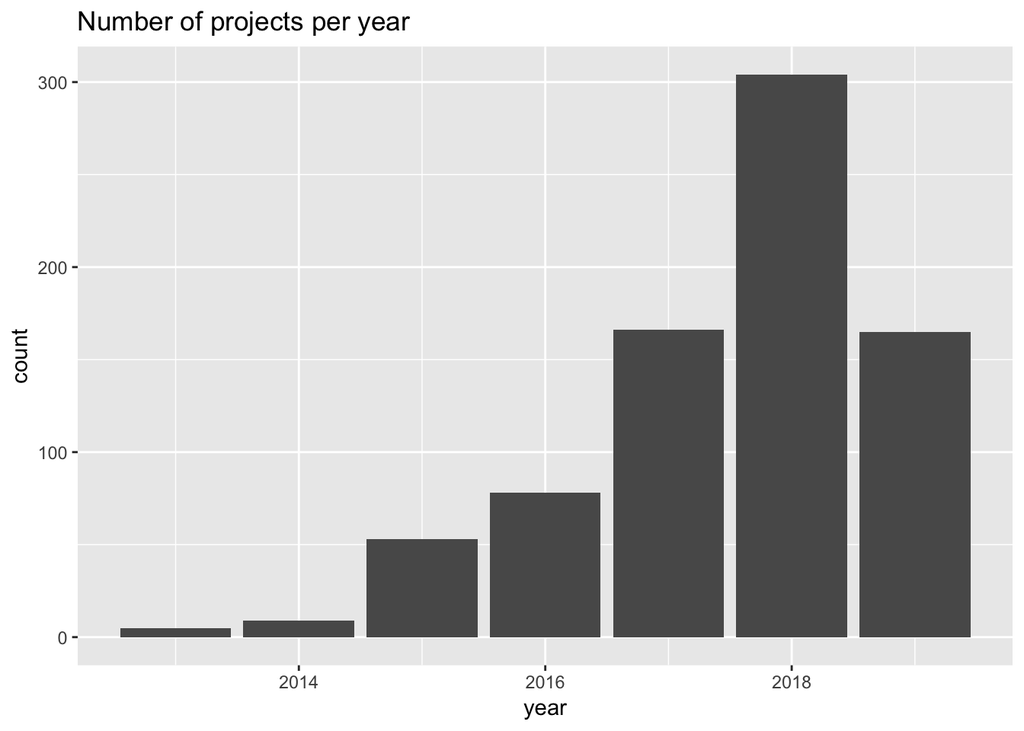

```r
ggplot(dat) + geom_bar(aes(year), stat="count") + ggtitle("Number of projects per year")
```

There are very few projects before 2015, and so for simplicity’s sake and to simplify the model just a tad, we remove 2013 and 2014.

```r
dat = dat[dat$year >= 2015, ]
```

### Projects per month

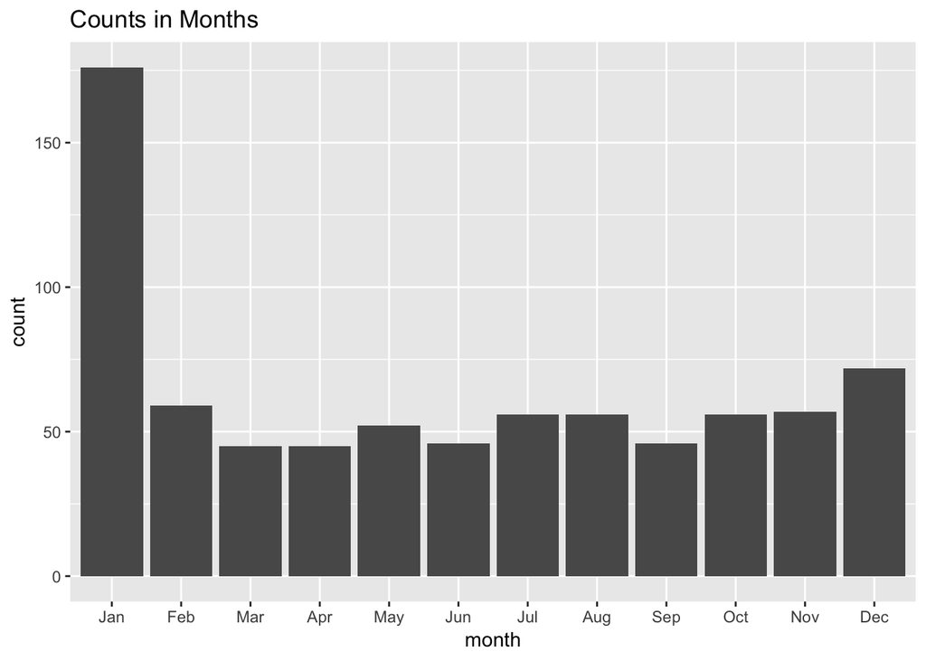

```r
dat$month <- factor(dat$month)

dat %>%
  ggplot() + labs(title="Counts in Months") +
  geom_bar(aes(month)) +
  scale_x_discrete(labels = c("Jan", "Feb", "Mar", "Apr", "May", "Jun", "Jul", "Aug", "Sep", "Oct", "Nov", "Dec"))
```

Interestingly, there are a ton of January projects. This might have to do with scraping the site which lists projects chronologically.

### Projects per day of the week

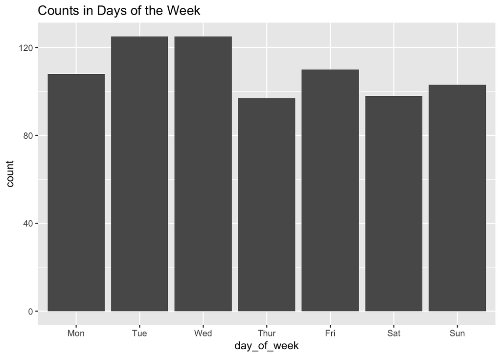

```r
dat$day_of_week <- factor(dat$day_of_week)

dat %>%
  ggplot() + labs(title="Counts in Days of the Week") +
  geom_bar(aes(day_of_week)) +
  scale_x_discrete(labels = c("Mon", "Tue", "Wed", "Thur", "Fri", "Sat", "Sun"))
```

### Projects from the US

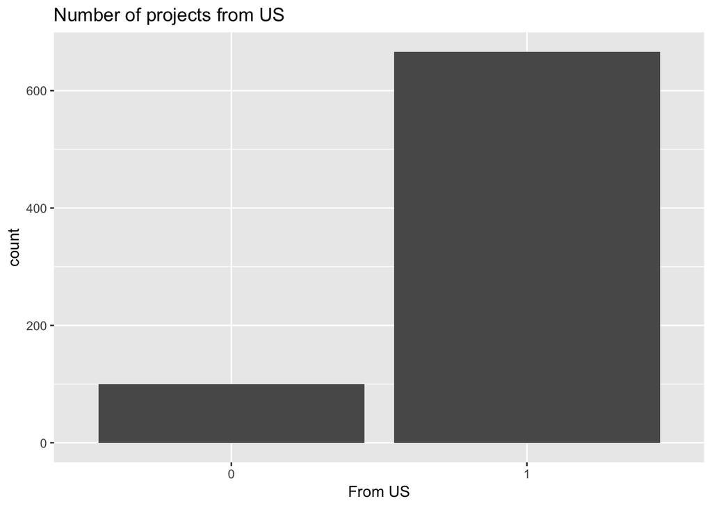

```r
ggplot(dat) + geom_bar(aes(x=factor(from_US)), stat="count") + labs(x="From US", title="Number of projects from US")
```

Most projects are US based. Reduce the model complexity by restricting to US then.

```r
dat <- dat[dat$from_US == 1, ]
```

### Project durations

Kickstarter projects are usually given 30 days to meet their goal, so most projects revolve around that duration. Some are shorter and some are longer though. Categorize each of those bins.

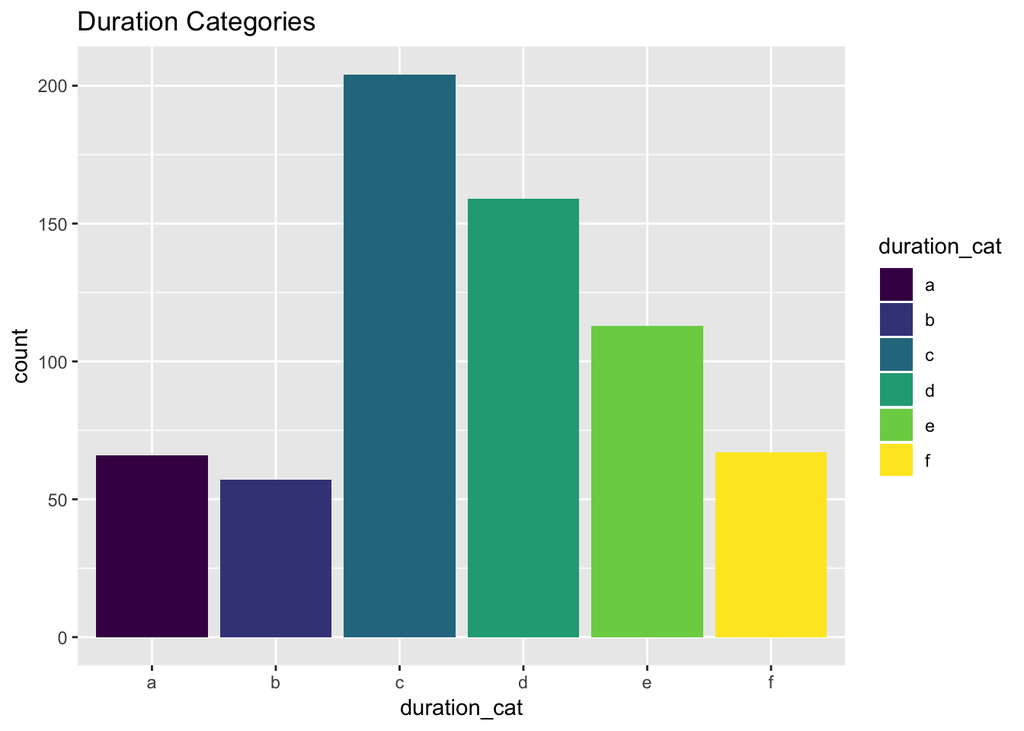

```r
probs = c(0.0, 0.1, 0.25, 0.5, 0.75, 0.9, 1.0)
labs = c("a", "b", "c", "d", "e", "f")
quants = quantile(dat$duration_float, probs, names=F)

dat$duration_cat = ""

for (i in 1:6) {
  dat[dat$duration_float >= quants[i] & dat$duration_float <= quants[i+1], ]$duration_cat = labs[i]
}
dat$duration_cat = factor(dat$duration_cat, ordered = T, levels = labs)

dat %>%
  ggplot() + labs(title = "Duration Categories") +
  geom_bar(aes(duration_cat, fill=duration_cat), position="dodge")
```

### Metaphor instantiation

Where is the first metaphor instantiated? If it comes within the first quarter of the text, does that make a difference, compared to the second quarter or second half? Categorize each project.

[figure not shown]

```r
dat$inst = ""
dat[dat$first_instantiation == -1.0, ]$inst = "none"
dat[dat$first_instantiation >= 0 & dat$first_instantiation < 0.25, ]$inst = "firstquarter"
dat[dat$first_instantiation >= 0.25 & dat$first_instantiation < 0.5, ]$inst = "secondquarter"
dat[dat$first_instantiation >= 0.5, ]$inst = "secondhalf"

dat$inst = factor(dat$inst)

dat %>%
  ggplot() + labs(x="First Metaphor Instantiation Category", title="Counts in First Metaphor Instantiation Categories") +
  geom_bar(aes(inst)) +
  scale_x_discrete(labels = c("No Metaphor", "First Quarter", "Second Quarter", "Second Half"))
```

We scale/z-score the continuous variables according to how we wish to interpret the coefficients of the model. From Andrew Gelman: “Standardizing puts things on an approximately common scale …. (Standarize for) comparing coefficients for different predictors within a model”. Binary and categorical variables are left as is.

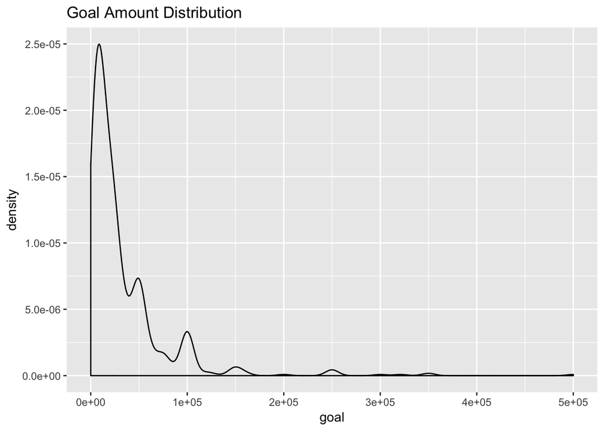

```r
dat$goal_sc <- scale(dat$goal)

dat %>%
  ggplot() + labs(title="Goal Amount Distribution") +
  geom_density(aes(goal))
```

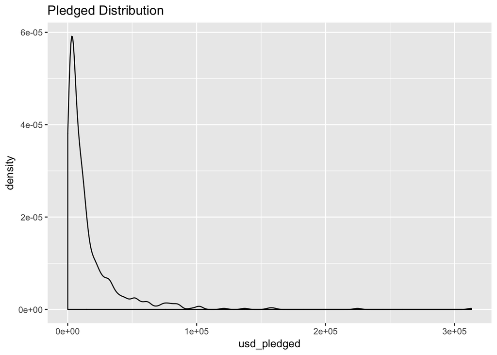

```r
dat %>%
  ggplot() + labs(title="Pledged Distribution") +
  geom_density(aes(usd_pledged))
```

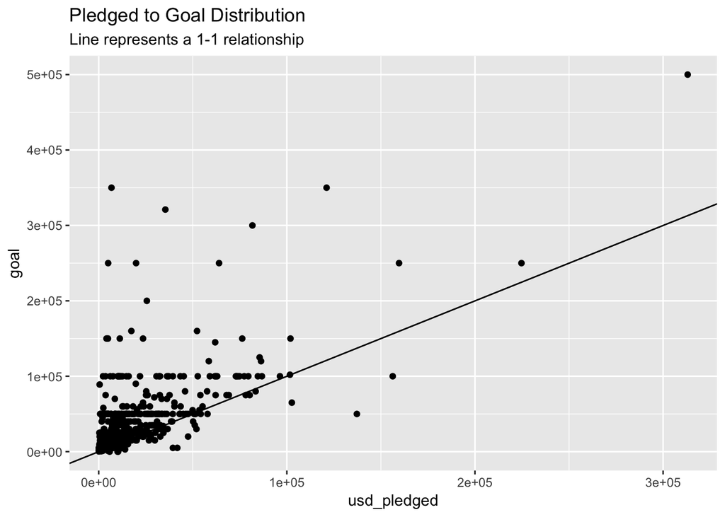

```r
dat %>%
  ggplot() + labs(title="Pledged to Goal Distribution", subtitle = "Line represents a 1-1 relationship") +
  geom_point(aes(usd_pledged, goal)) +
  geom_abline(intercept = 0, slope = 1)
```

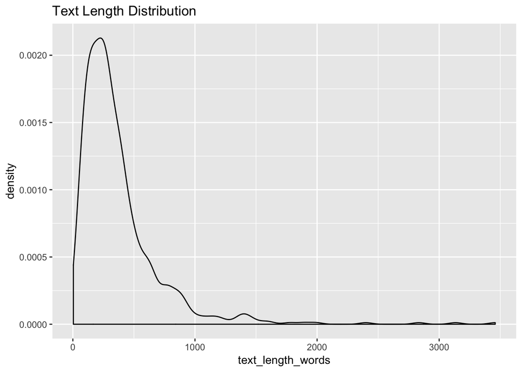

```r
dat$text_length_words_sc <- scale(dat$text_length_words)

dat %>%
  ggplot() + labs(title="Text Length Distribution") +
  geom_density(aes(text_length_words))
```

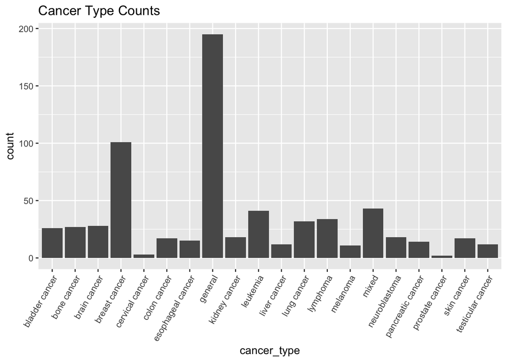

```r
dat %>%
  ggplot() + labs(title="Cancer Type Counts") +
  geom_bar(aes(x=cancer_type)) +
  theme(axis.text.x=element_text(angle = 60, hjust=1))
```

### Project metaphors

No metaphor (b = 0 & j = 0) Any metaphor (b > 0 || j > 0) Some journey (j > 0) Some battle (b > 0) Some journey, no battle (b = 0 & j > 0) Some battle, no journey (b > 0 & j = 0) Some both (b > 0 & j > 0)

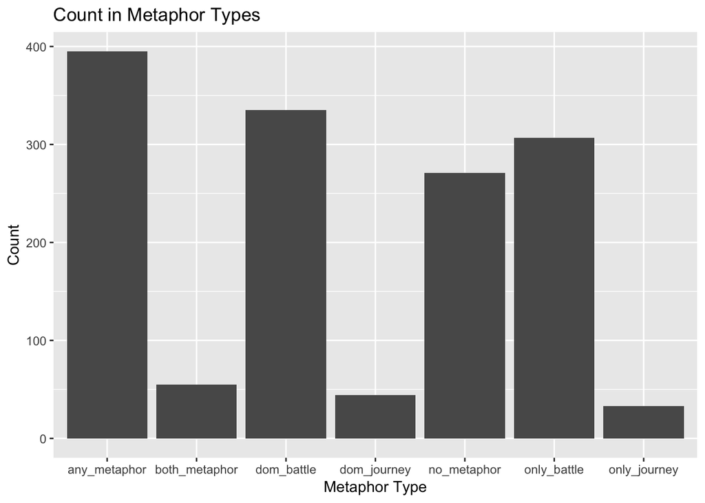

```r
dat$no_metaphor = dat$battle_salience == 0.0 & dat$journey_salience == 0.0
dat$any_metaphor = 1 - dat$no_metaphor
dat$dom_journey = dat$journey_salience > dat$battle_salience
dat$dom_battle = dat$battle_salience > dat$journey_salience
dat$only_journey = dat$journey_salience > 0 & dat$battle_salience == 0.0
dat$only_battle = dat$journey_salience == 0.0 & dat$battle_salience > 0
dat$both_metaphor = dat$battle_salience > 0.0 & dat$journey_salience > 0.0

metaphor_counts = data.frame(counts = colSums(dat[, c("no_metaphor", "any_metaphor", "dom_journey", "dom_battle", "only_journey", "only_battle", "both_metaphor")]))

ggplot() + labs(x="Metaphor Type", y="Count", title="Count in Metaphor Types") +
  geom_bar(stat="identity", aes(x=row.names(metaphor_counts), y=metaphor_counts$counts))
```

Seem like comprehensive sources: https://bbolker.github.io/mixedmodels-misc/glmmFAQ.html#model-definition https://ase.tufts.edu/gsc/gradresources/guidetomixedmodelsinr/mixed%20model%20guide.html

# Primary Analyses

We are interested in the effect that metaphor presence has on the funding status of a project.

**DV**: status, backers, mean donation **IV**: Goal amount, staff pick, category, text length words, duration category, year, metaphor instantiation, metaphor family salience, metaphor productivity

Various sources were used to determine what should be a random effect and what should be fixed, and how to model interactions and correlations between variables, including:

- Data Analysis Using Regression and Multilevel/Hierarchical Models (Gelman and Hill, 2006)
- Interactions in Generalized Linear Models: Theoretical Issues and an Application to Personal Vote-Earning Attributes (Tsai and Gill, 2013)
- Should I Use Fixed or Random Effects? (Clark and Linzer, 2012)
- Random effects structure for confirmatory hypothesis testing: Keep it maximal (Barr et al., 2013)
- https://stats.stackexchange.com/questions/13166/rs-lmer-cheat-sheet
- https://stats.stackexchange.com/questions/4700/what-is-the-difference-between-fixed-effect-random-effect-and-mixed-effect-mode/151800#151800
- https://rlbarter.github.io/Practical-Statistics/2017/03/03/fixed-mixed-and-random-effects/
- https://stats.stackexchange.com/questions/323273/what-to-do-with-random-effects-correlation-that-equals-1-or-1
- Fitting linear mixed-effects models using lme4 (Bates et al., 2014)

# Status

```r
nrow(dat)
```

```
## [1] 666
```

In total, we have 666 iid samples to work with.

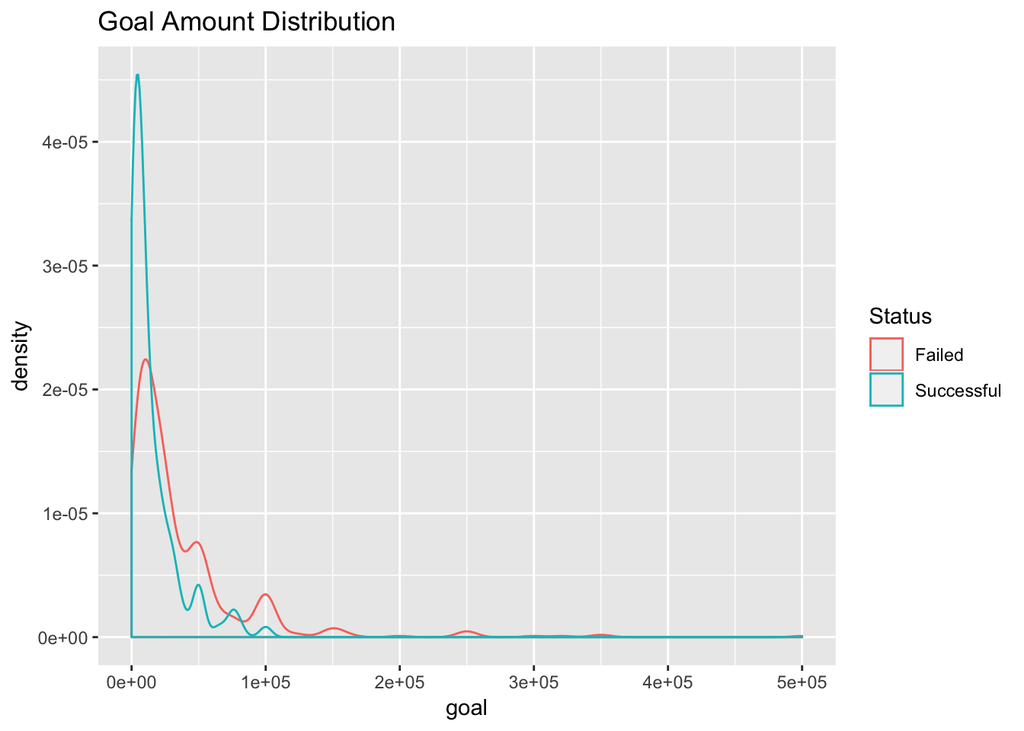

```r
dat %>%
  ggplot() + labs(title="Goal Amount Distribution") + guides(color=guide_legend(title="Status")) +
  geom_density(aes(goal, color=fct_recode(factor(status), "Successful"="1", "Failed"="0")))
```

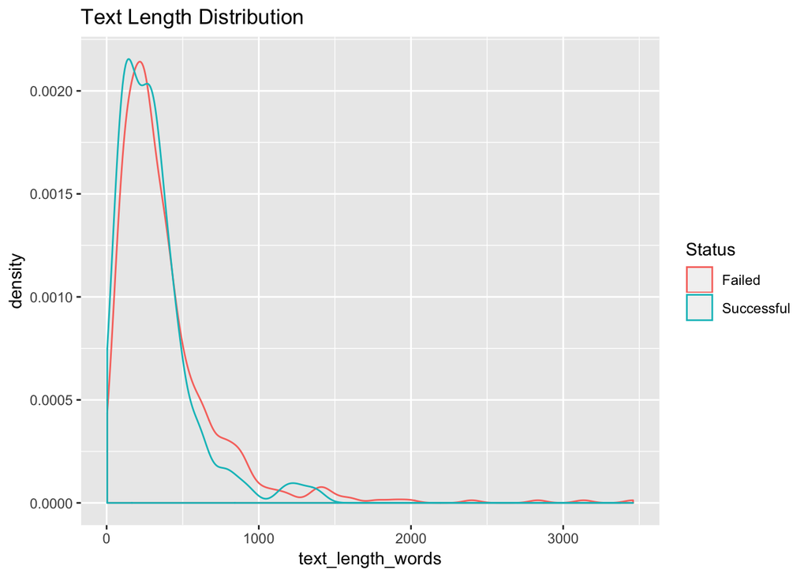

```r
dat %>%
  ggplot() + labs(title="Text Length Distribution") + guides(color=guide_legend(title="Status")) +
  geom_density(aes(text_length_words, color=fct_recode(factor(status), "Successful"="1", "Failed"="0")))
```

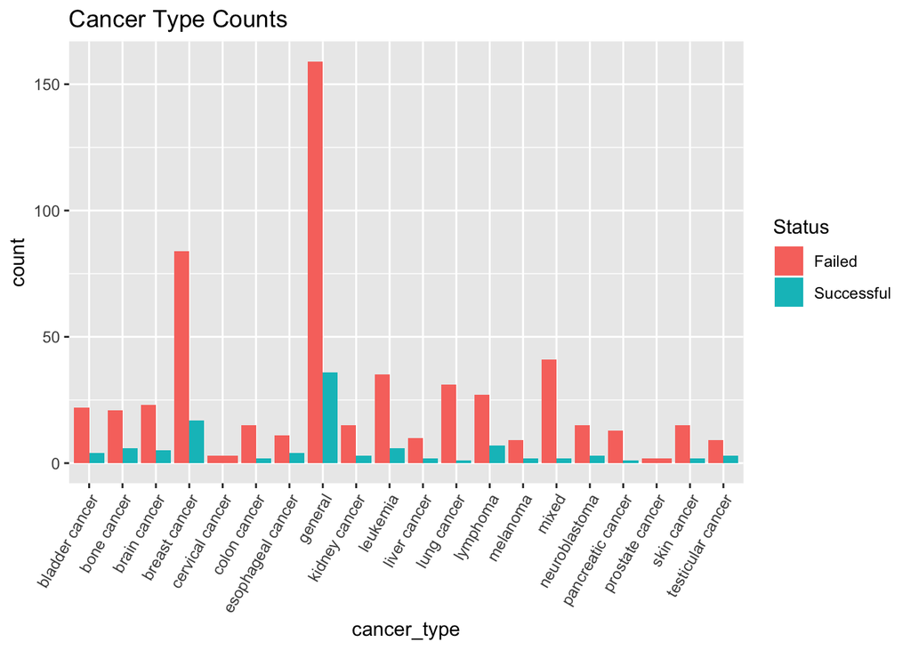

```r
dat %>%
  ggplot() + labs(title="Cancer Type Counts") + guides(fill=guide_legend(title="Status")) +
  geom_bar(aes(x=cancer_type, fill=fct_recode(factor(status), "Successful"="1", "Failed"="0")), position="dodge") +
  theme(axis.text.x=element_text(angle = 60, hjust=1))
```

Removed all random variabes except year because they didn’t help explain any variance in the data beyond what the residuals could capture.

Nesting and Chi2 differences: https://www.psychologie.uzh.ch/dam/jcr:ffffffff-b371-2797-0000-00000fda8f29/chisquare_diff_en.pdf

## Model status

```r
# no fixed effects, only random
mod.none <- glmer(status ~ (1|year),
                  data = dat, family = "binomial", nAGQ = 0)


# add duration category
mod.dur <- glmer(status ~ duration_cat + (1|year),
                       data = dat, family = "binomial", nAGQ = 0)

# add length of text (in words)
mod.dur.length <- glmer(status ~ text_length_words_sc + duration_cat + (1|year),
                              data = dat, family = "binomial", nAGQ = 0)

# add scaled goal amount
mod.dur.length.goal <- glmer(status ~ goal_sc + text_length_words_sc + duration_cat + (1|year),
                                   data = dat, family = "binomial", nAGQ = 0)

# add first instantiation
mod.dur.length.goal.inst <- glmer(status ~ inst + goal_sc + text_length_words_sc + duration_cat + (1|year),
                                         data = dat, family = "binomial", nAGQ = 0)

anova(mod.none, mod.dur, test='Chisq')
```

```
## Data: dat
## Models:
## mod.none: status ~ (1 | year)
## mod.dur: status ~ duration_cat + (1 | year)
##          Df    AIC    BIC  logLik deviance  Chisq Chi Df Pr(>Chisq)
## mod.none  2 587.77 596.77 -291.88   583.77
## mod.dur   7 584.39 615.90 -285.20   570.39 13.378      5    0.02008 *
## ---
## Signif. codes:  0 '***' 0.001 '**' 0.01 '*' 0.05 '.' 0.1 ' ' 1
```

```r
anova(mod.dur, mod.dur.length, test='Chisq')
```

```
## Data: dat
## Models:
## mod.dur: status ~ duration_cat + (1 | year)
## mod.dur.length: status ~ text_length_words_sc + duration_cat + (1 | year)
##                Df    AIC    BIC  logLik deviance  Chisq Chi Df Pr(>Chisq)
## mod.dur         7 584.39 615.90 -285.20   570.39
## mod.dur.length  8 580.78 616.79 -282.39   564.78 5.6106      1    0.01785
##
## mod.dur
## mod.dur.length *
## ---
## Signif. codes:  0 '***' 0.001 '**' 0.01 '*' 0.05 '.' 0.1 ' ' 1
```

```r
anova(mod.dur.length, mod.dur.length.goal, test='Chisq')
```

```
## Data: dat
## Models:
## mod.dur.length: status ~ text_length_words_sc + duration_cat + (1 | year)
## mod.dur.length.goal: status ~ goal_sc + text_length_words_sc + duration_cat + (1 |
## mod.dur.length.goal:     year)
##                     Df    AIC    BIC  logLik deviance  Chisq Chi Df
## mod.dur.length       8 580.78 616.79 -282.39   564.78
## mod.dur.length.goal  9 546.29 586.80 -264.14   528.29 36.495      1
##                     Pr(>Chisq)
## mod.dur.length
## mod.dur.length.goal  1.531e-09 ***
## ---
## Signif. codes:  0 '***' 0.001 '**' 0.01 '*' 0.05 '.' 0.1 ' ' 1
```

```r
anova(mod.dur.length.goal, mod.dur.length.goal.inst, test='Chisq')
```

```
## Data: dat
## Models:
## mod.dur.length.goal: status ~ goal_sc + text_length_words_sc + duration_cat + (1 |
## mod.dur.length.goal:     year)
## mod.dur.length.goal.inst: status ~ inst + goal_sc + text_length_words_sc + duration_cat +
## mod.dur.length.goal.inst:     (1 | year)
##                          Df    AIC    BIC  logLik deviance Chisq Chi Df
## mod.dur.length.goal       9 546.29 586.80 -264.14   528.29
## mod.dur.length.goal.inst 12 550.43 604.45 -263.21   526.43 1.857      3
##                          Pr(>Chisq)
## mod.dur.length.goal
## mod.dur.length.goal.inst     0.6026
```

The final base model before adding metaphor variables:

```r
summary(mod.dur.length.goal.inst)
```

```
## Generalized linear mixed model fit by maximum likelihood (Adaptive
##   Gauss-Hermite Quadrature, nAGQ = 0) [glmerMod]
##  Family: binomial  ( logit )
## Formula: status ~ inst + goal_sc + text_length_words_sc + duration_cat +
##     (1 | year)
##    Data: dat
##
##      AIC      BIC   logLik deviance df.resid
##    550.4    604.4   -263.2    526.4      654
##
## Scaled residuals:
##     Min      1Q  Median      3Q     Max
## -0.7691 -0.5164 -0.3577 -0.1368  6.6599
##
## Random effects:
##  Groups Name        Variance Std.Dev.
##  year   (Intercept) 0        0
## Number of obs: 666, groups:  year, 5
##
## Fixed effects:
##                      Estimate Std. Error z value Pr(>|z|)
## (Intercept)           -2.2930     0.2854  -8.035 9.32e-16 ***
## instnone               0.2029     0.2919   0.695   0.4871
## instsecondhalf        -0.1396     0.3623  -0.385   0.7001
## instsecondquarter      0.3323     0.3909   0.850   0.3953
## goal_sc               -1.4082     0.3188  -4.418 9.97e-06 ***
## text_length_words_sc  -0.1071     0.1423  -0.753   0.4517
## duration_cat.L         1.2443     0.5031   2.473   0.0134 *
## duration_cat.Q        -1.0442     0.4560  -2.290   0.0220 *
## duration_cat.C         0.8819     0.3815   2.312   0.0208 *
## duration_cat^4        -0.6445     0.3046  -2.116   0.0343 *
## duration_cat^5         0.2623     0.2330   1.126   0.2603
## ---
## Signif. codes:  0 '***' 0.001 '**' 0.01 '*' 0.05 '.' 0.1 ' ' 1
##
## Correlation of Fixed Effects:
##             (Intr) instnn instscndh instscndq gol_sc txt___ drt_.L drt_.Q
## instnone    -0.667
## instscndhlf -0.584  0.527
## instscndqrt -0.525  0.500  0.398
## goal_sc      0.361  0.072 -0.074    -0.010
## txt_lngth__ -0.083  0.205  0.015     0.040    -0.115
## duratn_ct.L -0.358  0.026  0.054     0.027    -0.067 -0.029
## duratn_ct.Q  0.380 -0.022 -0.019    -0.018    -0.022 -0.012 -0.565
## duratn_ct.C -0.242  0.005  0.056     0.015    -0.087  0.029  0.557 -0.481
## duratn_ct^4  0.109  0.009 -0.024     0.072     0.046  0.030 -0.230  0.447
## duratn_ct^5 -0.021  0.005 -0.012    -0.008    -0.031 -0.040  0.093 -0.169
##             drt_.C drt_^4
## instnone
## instscndhlf
## instscndqrt
## goal_sc
## txt_lngth__
## duratn_ct.L
## duratn_ct.Q
## duratn_ct.C
## duratn_ct^4 -0.390
## duratn_ct^5  0.313 -0.172
```

## Add metaphors

Use `nAQG=0` because `nAQG=1` cannot converge in a reasonable number (10,000) of iterations

See https://stats.stackexchange.com/questions/77313/why-cant-i-match-glmer-family-binomial-output-with-manual-implementation-of-g and https://www.rdocumentation.org/packages/lme4/versions/1.1-19/topics/glmer

```r
mod.no_metaphor = glmer(status ~ no_metaphor + goal_sc + text_length_words_sc + duration_cat + inst + (1|year),
                        data = dat, family = "binomial", nAGQ = 0)
```

```
## fixed-effect model matrix is rank deficient so dropping 1 column / coefficient
```

```r
mod.any_metaphor = glmer(status ~ any_metaphor + goal_sc + text_length_words_sc + duration_cat + inst + (1|year),
                        data = dat, family = "binomial", nAGQ = 0)
```

```
## fixed-effect model matrix is rank deficient so dropping 1 column / coefficient
```

```r
mod.dom_journey = glmer(status ~ dom_journey + goal_sc + text_length_words_sc + duration_cat + inst + (1|year),
                        data = dat, family = "binomial", nAGQ = 0)
mod.dom_journey.prod = glmer(status ~ journey_prod + dom_journey + goal_sc + text_length_words_sc + duration_cat + inst + (1|year),
                        data = dat, family = "binomial", nAGQ = 0)
mod.dom_battle = glmer(status ~ dom_battle + goal_sc + text_length_words_sc + duration_cat + inst + (1|year),
                        data = dat, family = "binomial", nAGQ = 0)
mod.dom_battle.prod = glmer(status ~ battle_prod + dom_battle + goal_sc + text_length_words_sc + duration_cat + inst + (1|year),
                        data = dat, family = "binomial", nAGQ = 0)
mod.only_journey = glmer(status ~ only_journey + goal_sc + text_length_words_sc + duration_cat + inst + (1|year),
                        data = dat, family = "binomial", nAGQ = 0)
mod.only_battle = glmer(status ~ only_battle + goal_sc + text_length_words_sc + duration_cat + inst + (1|year),
                        data = dat, family = "binomial", nAGQ = 0)
mod.both_metaphor = glmer(status ~ both_metaphor + goal_sc + text_length_words_sc + duration_cat + inst + (1|year),
                        data = dat, family = "binomial", nAGQ = 0)

anova(mod.dur.length.goal.inst, mod.no_metaphor)
```

```
## Data: dat
## Models:
## mod.dur.length.goal.inst: status ~ inst + goal_sc + text_length_words_sc + duration_cat +
## mod.dur.length.goal.inst:     (1 | year)
## mod.no_metaphor: status ~ no_metaphor + goal_sc + text_length_words_sc + duration_cat +
## mod.no_metaphor:     inst + (1 | year)
##                          Df    AIC    BIC  logLik deviance Chisq Chi Df
## mod.dur.length.goal.inst 12 550.43 604.45 -263.21   526.43
## mod.no_metaphor          12 550.43 604.45 -263.21   526.43     0      0
##                          Pr(>Chisq)
## mod.dur.length.goal.inst
## mod.no_metaphor           < 2.2e-16 ***
## ---
## Signif. codes:  0 '***' 0.001 '**' 0.01 '*' 0.05 '.' 0.1 ' ' 1
```

```r
anova(mod.dur.length.goal.inst, mod.any_metaphor)
```

```
## Data: dat
## Models:
## mod.dur.length.goal.inst: status ~ inst + goal_sc + text_length_words_sc + duration_cat +
## mod.dur.length.goal.inst:     (1 | year)
## mod.any_metaphor: status ~ any_metaphor + goal_sc + text_length_words_sc + duration_cat +
## mod.any_metaphor:     inst + (1 | year)
##                          Df    AIC    BIC  logLik deviance Chisq Chi Df
## mod.dur.length.goal.inst 12 550.43 604.45 -263.21   526.43
## mod.any_metaphor         12 550.43 604.45 -263.21   526.43     0      0
##                          Pr(>Chisq)
## mod.dur.length.goal.inst
## mod.any_metaphor          < 2.2e-16 ***
## ---
## Signif. codes:  0 '***' 0.001 '**' 0.01 '*' 0.05 '.' 0.1 ' ' 1
```

```r
anova(mod.dur.length.goal.inst, mod.dom_journey)
```

```
## Data: dat
## Models:
## mod.dur.length.goal.inst: status ~ inst + goal_sc + text_length_words_sc + duration_cat +
## mod.dur.length.goal.inst:     (1 | year)
## mod.dom_journey: status ~ dom_journey + goal_sc + text_length_words_sc + duration_cat +
## mod.dom_journey:     inst + (1 | year)
##                          Df    AIC    BIC  logLik deviance  Chisq Chi Df
## mod.dur.length.goal.inst 12 550.43 604.45 -263.21   526.43
## mod.dom_journey          13 550.37 608.88 -262.18   524.37 2.0645      1
##                          Pr(>Chisq)
## mod.dur.length.goal.inst
## mod.dom_journey              0.1508
```

```r
anova(mod.dom_journey, mod.dom_journey.prod)
```

```
## Data: dat
## Models:
## mod.dom_journey: status ~ dom_journey + goal_sc + text_length_words_sc + duration_cat +
## mod.dom_journey:     inst + (1 | year)
## mod.dom_journey.prod: status ~ journey_prod + dom_journey + goal_sc + text_length_words_sc +
## mod.dom_journey.prod:     duration_cat + inst + (1 | year)
##                      Df    AIC    BIC  logLik deviance  Chisq Chi Df
## mod.dom_journey      13 550.37 608.88 -262.18   524.37
## mod.dom_journey.prod 14 550.96 613.98 -261.48   522.96 1.4018      1
##                      Pr(>Chisq)
## mod.dom_journey
## mod.dom_journey.prod     0.2364
```

```r
anova(mod.dur.length.goal.inst, mod.dom_battle)
```

```
## Data: dat
## Models:
## mod.dur.length.goal.inst: status ~ inst + goal_sc + text_length_words_sc + duration_cat +
## mod.dur.length.goal.inst:     (1 | year)
## mod.dom_battle: status ~ dom_battle + goal_sc + text_length_words_sc + duration_cat +
## mod.dom_battle:     inst + (1 | year)
##                          Df    AIC    BIC  logLik deviance  Chisq Chi Df
## mod.dur.length.goal.inst 12 550.43 604.45 -263.21   526.43
## mod.dom_battle           13 552.20 610.72 -263.10   526.20 0.2263      1
##                          Pr(>Chisq)
## mod.dur.length.goal.inst
## mod.dom_battle               0.6343
```

```r
anova(mod.dom_battle, mod.dom_battle.prod)
```

```
## Data: dat
## Models:
## mod.dom_battle: status ~ dom_battle + goal_sc + text_length_words_sc + duration_cat +
## mod.dom_battle:     inst + (1 | year)
## mod.dom_battle.prod: status ~ battle_prod + dom_battle + goal_sc + text_length_words_sc +
## mod.dom_battle.prod:     duration_cat + inst + (1 | year)
##                     Df    AIC    BIC  logLik deviance  Chisq Chi Df
## mod.dom_battle      13 552.20 610.72 -263.10   526.20
## mod.dom_battle.prod 14 553.86 616.88 -262.93   525.86 0.3416      1
##                     Pr(>Chisq)
## mod.dom_battle
## mod.dom_battle.prod     0.5589
```

```r
anova(mod.dur.length.goal.inst, mod.only_journey)
```

```
## Data: dat
## Models:
## mod.dur.length.goal.inst: status ~ inst + goal_sc + text_length_words_sc + duration_cat +
## mod.dur.length.goal.inst:     (1 | year)
## mod.only_journey: status ~ only_journey + goal_sc + text_length_words_sc + duration_cat +
## mod.only_journey:     inst + (1 | year)
##                          Df    AIC    BIC  logLik deviance  Chisq Chi Df
## mod.dur.length.goal.inst 12 550.43 604.45 -263.21   526.43
## mod.only_journey         13 550.40 608.92 -262.20   524.40 2.0321      1
##                          Pr(>Chisq)
## mod.dur.length.goal.inst
## mod.only_journey              0.154
```

```r
anova(mod.dur.length.goal.inst, mod.only_battle)
```

```
## Data: dat
## Models:
## mod.dur.length.goal.inst: status ~ inst + goal_sc + text_length_words_sc + duration_cat +
## mod.dur.length.goal.inst:     (1 | year)
## mod.only_battle: status ~ only_battle + goal_sc + text_length_words_sc + duration_cat +
## mod.only_battle:     inst + (1 | year)
##                          Df    AIC    BIC  logLik deviance  Chisq Chi Df
## mod.dur.length.goal.inst 12 550.43 604.45 -263.21   526.43
## mod.only_battle          13 552.24 610.76 -263.12   526.24 0.1874      1
##                          Pr(>Chisq)
## mod.dur.length.goal.inst
## mod.only_battle              0.6651
```

```r
anova(mod.dur.length.goal.inst, mod.both_metaphor)
```

```
## Data: dat
## Models:
## mod.dur.length.goal.inst: status ~ inst + goal_sc + text_length_words_sc + duration_cat +
## mod.dur.length.goal.inst:     (1 | year)
## mod.both_metaphor: status ~ both_metaphor + goal_sc + text_length_words_sc + duration_cat +
## mod.both_metaphor:     inst + (1 | year)
##                          Df    AIC    BIC  logLik deviance Chisq Chi Df
## mod.dur.length.goal.inst 12 550.43 604.45 -263.21   526.43
## mod.both_metaphor        13 552.09 610.61 -263.05   526.09 0.338      1
##                          Pr(>Chisq)
## mod.dur.length.goal.inst
## mod.both_metaphor             0.561
```

# Number of Backers

```r
library(glmmTMB)
```

```r
nrow(dat[dat$backers > 1200, ])
```

```
## [1] 9
```

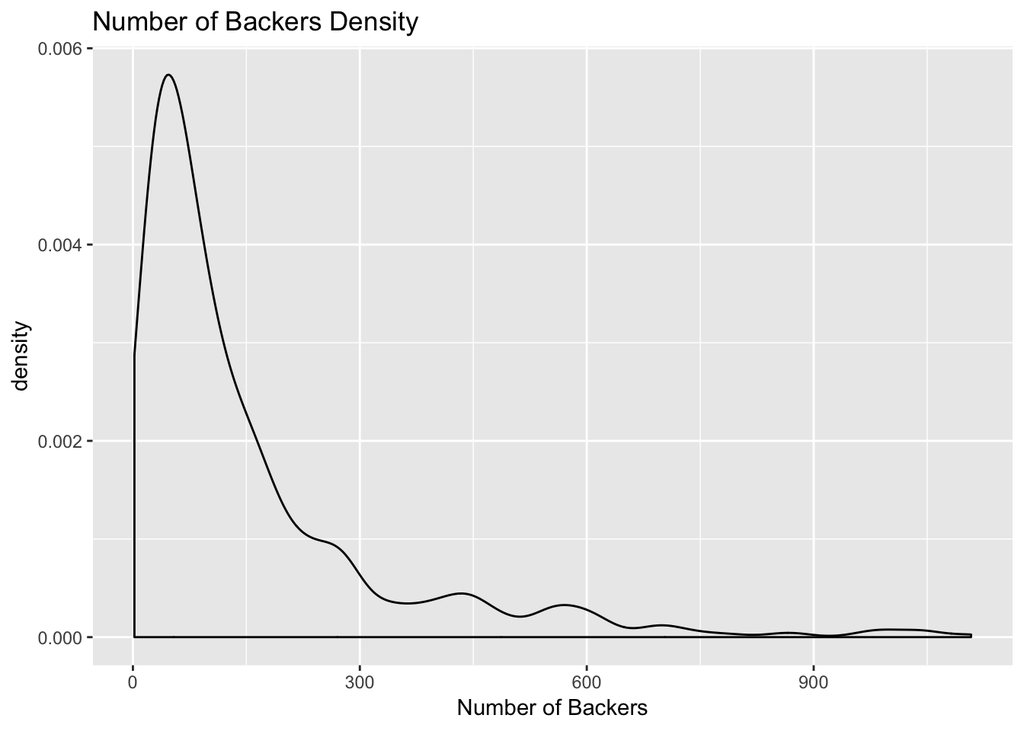

```r
ggplot() + labs(x="Number of Backers", title="Number of Backers Density") +
  geom_density(aes(dat$backers[dat$backers < 1200]))
```

We limit to 1200 because removing the outliers leaves us with a nicely shaped distribution.

```r
dat.b <- dat[dat$backers < 1200, ]
```

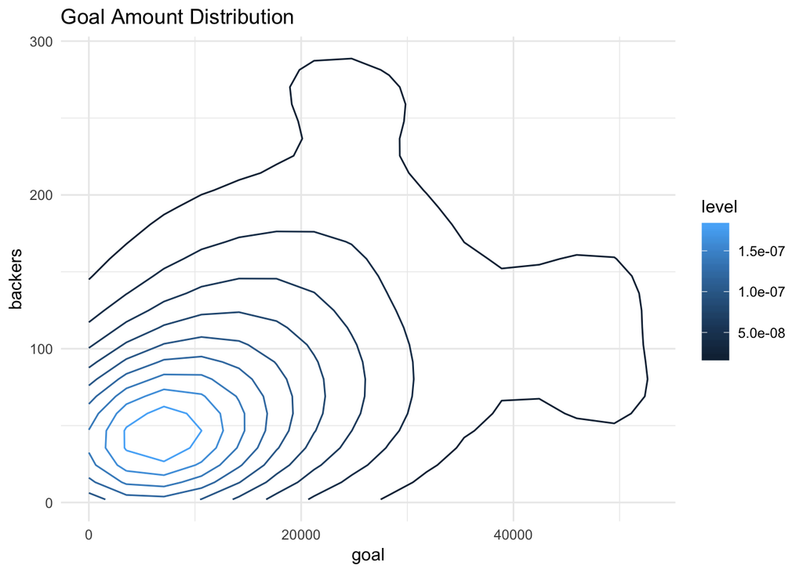

```r
dat.b %>%
  ggplot(aes(goal, backers)) + labs(title="Goal Amount Distribution") +
  geom_density2d(aes(color=..level..)) +
  theme_minimal()
```

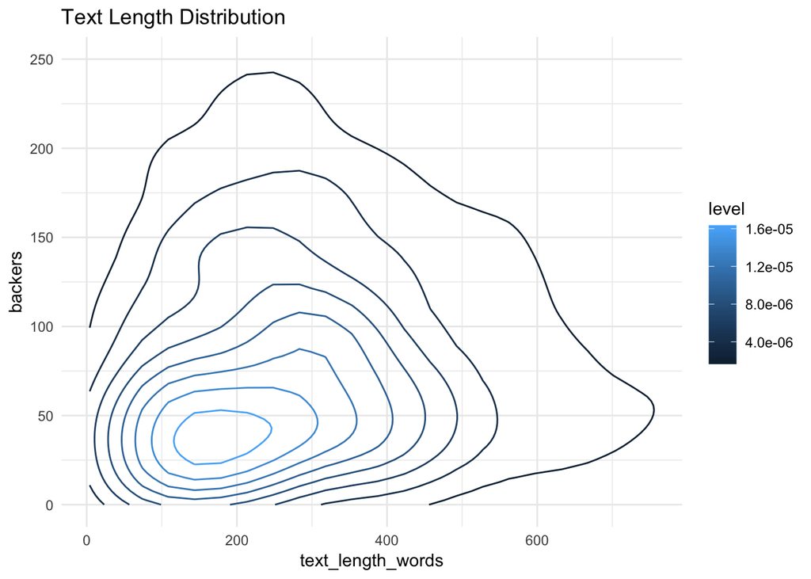

```r
dat.b %>%
  ggplot(aes(text_length_words, backers)) + labs(title="Text Length Distribution") +
  geom_density2d(aes(color=..level..)) + ylim(0, 250) +
  theme_minimal()
```

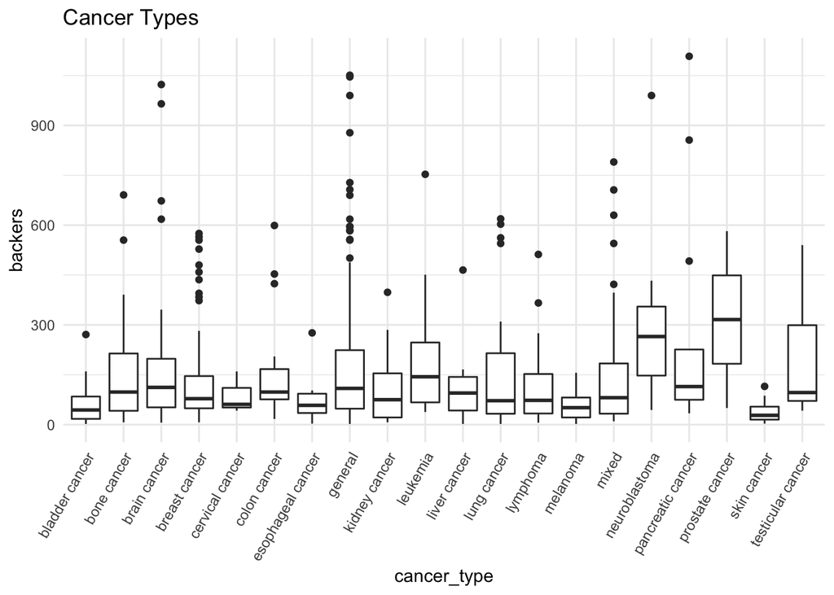

```r
dat.b %>%
  ggplot(aes(cancer_type, backers)) + labs(title="Cancer Types") +
  geom_boxplot() +
  theme_minimal() +
  theme(axis.text.x=element_text(angle = 60, hjust=1))
```

## Model backers

```r
# no fixed effects, only random
mod.none <- glmmTMB(backers ~ (1|year), data = dat.b, family="nbinom2")

# add duration category
mod.dur <- glmmTMB(backers ~ duration_cat + (1|year), data = dat.b, family="nbinom2")

# add length of text (in words)
mod.dur.length <- glmmTMB(backers ~ text_length_words_sc + duration_cat + (1|year), data = dat.b, family="nbinom2")

# add scaled goal amount
mod.dur.length.goal <- glmmTMB(backers ~ goal_sc + text_length_words_sc + duration_cat + (1|year), data = dat.b, family="nbinom2")

# add first instantiation
mod.dur.length.goal.inst <- glmmTMB(backers ~ inst + goal_sc + text_length_words_sc + duration_cat + (1|year), data = dat.b, family="nbinom2")

anova(mod.none, mod.dur, test='Chisq')
```

```
## Data: dat.b
## Models:
## mod.none: backers ~ (1 | year), zi=~0, disp=~1
## mod.dur: backers ~ duration_cat + (1 | year), zi=~0, disp=~1
##          Df    AIC    BIC  logLik deviance  Chisq Chi Df Pr(>Chisq)
## mod.none  3 7918.5 7932.0 -3956.3   7912.5
## mod.dur   8 7906.4 7942.3 -3945.2   7890.4 22.177      5  0.0004845 ***
## ---
## Signif. codes:  0 '***' 0.001 '**' 0.01 '*' 0.05 '.' 0.1 ' ' 1
```

```r
anova(mod.dur, mod.dur.length, test='Chisq')
```

```
## Data: dat.b
## Models:
## mod.dur: backers ~ duration_cat + (1 | year), zi=~0, disp=~1
## mod.dur.length: backers ~ text_length_words_sc + duration_cat + (1 | year), zi=~0, disp=~1
##                Df    AIC    BIC  logLik deviance  Chisq Chi Df Pr(>Chisq)
## mod.dur         8 7906.4 7942.3 -3945.2   7890.4
## mod.dur.length  9 7884.9 7925.3 -3933.4   7866.9 23.495      1  1.253e-06
##
## mod.dur
## mod.dur.length ***
## ---
## Signif. codes:  0 '***' 0.001 '**' 0.01 '*' 0.05 '.' 0.1 ' ' 1
```

```r
anova(mod.dur.length, mod.dur.length.goal, test='Chisq')
```

```
## Data: dat.b
## Models:
## mod.dur.length: backers ~ text_length_words_sc + duration_cat + (1 | year), zi=~0, disp=~1
## mod.dur.length.goal: backers ~ goal_sc + text_length_words_sc + duration_cat + (1 | , zi=~0, disp=~1
## mod.dur.length.goal:     year), zi=~0, disp=~1
##                     Df    AIC    BIC  logLik deviance  Chisq Chi Df
## mod.dur.length       9 7884.9 7925.3 -3933.4   7866.9
## mod.dur.length.goal 10 7692.3 7737.2 -3836.1   7672.3 194.58      1
##                     Pr(>Chisq)
## mod.dur.length
## mod.dur.length.goal  < 2.2e-16 ***
## ---
## Signif. codes:  0 '***' 0.001 '**' 0.01 '*' 0.05 '.' 0.1 ' ' 1
```

```r
anova(mod.dur.length.goal, mod.dur.length.goal.inst, test='Chisq')
```

```
## Data: dat.b
## Models:
## mod.dur.length.goal: backers ~ goal_sc + text_length_words_sc + duration_cat + (1 | , zi=~0, disp=~1
## mod.dur.length.goal:     year), zi=~0, disp=~1
## mod.dur.length.goal.inst: backers ~ inst + goal_sc + text_length_words_sc + duration_cat + , zi=~0, disp=~1
## mod.dur.length.goal.inst:     (1 | year), zi=~0, disp=~1
##                          Df    AIC    BIC  logLik deviance Chisq Chi Df
## mod.dur.length.goal      10 7692.3 7737.2 -3836.1   7672.3
## mod.dur.length.goal.inst 13 7694.8 7753.1 -3834.4   7668.8 3.497      3
##                          Pr(>Chisq)
## mod.dur.length.goal
## mod.dur.length.goal.inst     0.3211
```

```r
summary(mod.dur.length.goal.inst)
```

```
##  Family: nbinom2  ( log )
## Formula:
## backers ~ inst + goal_sc + text_length_words_sc + duration_cat +
##     (1 | year)
## Data: dat.b
##
##      AIC      BIC   logLik deviance df.resid
##   7694.8   7753.1  -3834.4   7668.8      644
##
## Random effects:
##
## Conditional model:
##  Groups Name        Variance  Std.Dev.
##  year   (Intercept) 8.351e-10 2.89e-05
## Number of obs: 657, groups:  year, 5
##
## Overdispersion parameter for nbinom2 family (): 1.44
##
## Conditional model:
##                       Estimate Std. Error z value Pr(>|z|)
## (Intercept)           4.912208   0.069034   71.16  < 2e-16 ***
## instnone             -0.091989   0.085943   -1.07   0.2845
## instsecondhalf        0.068377   0.095022    0.72   0.4718
## instsecondquarter    -0.032694   0.119317   -0.27   0.7841
## goal_sc               0.702855   0.058200   12.08  < 2e-16 ***
## text_length_words_sc  0.080568   0.033336    2.42   0.0157 *
## duration_cat.L        0.547850   0.102032    5.37  7.9e-08 ***
## duration_cat.Q       -0.126457   0.090469   -1.40   0.1622
## duration_cat.C        0.170613   0.093732    1.82   0.0687 .
## duration_cat^4       -0.147562   0.089460   -1.65   0.0991 .
## duration_cat^5        0.008151   0.071554    0.11   0.9093
## ---
## Signif. codes:  0 '***' 0.001 '**' 0.01 '*' 0.05 '.' 0.1 ' ' 1
```

## Add metaphors

```r
mod.no_metaphor = glmmTMB(backers ~ no_metaphor + goal_sc + text_length_words_sc + duration_cat + inst + (1|year),
                        data = dat.b, family = "nbinom2")
mod.any_metaphor = glmmTMB(backers ~ any_metaphor +goal_sc + text_length_words_sc + duration_cat + inst + (1|year),
                        data = dat.b, family = "nbinom2")
mod.dom_journey = glmmTMB(backers ~ dom_journey + goal_sc + text_length_words_sc + duration_cat + inst + (1|year),
                        data = dat.b, family = "nbinom2")
mod.dom_journey.prod = glmmTMB(backers ~ journey_prod + dom_journey + goal_sc + text_length_words_sc + duration_cat + inst + (1|year),
                        data = dat.b, family = "nbinom2")
mod.dom_battle = glmmTMB(backers ~ dom_battle + goal_sc + text_length_words_sc + duration_cat + inst + (1|year),
                        data = dat.b, family = "nbinom2")
mod.dom_battle.prod = glmmTMB(backers ~ battle_prod + dom_battle + goal_sc + text_length_words_sc + duration_cat + inst + (1|year),
                        data = dat.b, family = "nbinom2")
mod.only_journey = glmmTMB(backers ~ only_journey + goal_sc + text_length_words_sc + duration_cat + inst + (1|year),
                        data = dat.b, family = "nbinom2")
mod.only_battle = glmmTMB(backers ~ only_battle + goal_sc + text_length_words_sc + duration_cat + inst + (1|year),
                        data = dat.b, family = "nbinom2")
mod.both_metaphor = glmmTMB(backers ~ both_metaphor + goal_sc + text_length_words_sc + duration_cat + inst + (1|year),
                        data = dat.b, family = "nbinom2")

anova(mod.dur.length.goal.inst, mod.no_metaphor)
```

```
## Data: dat.b
## Models:
## mod.dur.length.goal.inst: backers ~ inst + goal_sc + text_length_words_sc + duration_cat + , zi=~0, disp=~1
## mod.dur.length.goal.inst:     (1 | year), zi=~0, disp=~1
## mod.no_metaphor: backers ~ no_metaphor + goal_sc + text_length_words_sc + duration_cat + , zi=~0, disp=~1
## mod.no_metaphor:     inst + (1 | year), zi=~0, disp=~1
##                          Df    AIC    BIC  logLik deviance Chisq Chi Df
## mod.dur.length.goal.inst 13 7694.8 7753.1 -3834.4   7668.8
## mod.no_metaphor          14                                           1
##                          Pr(>Chisq)
## mod.dur.length.goal.inst
## mod.no_metaphor
```

```r
anova(mod.dur.length.goal.inst, mod.any_metaphor)
```

```
## Data: dat.b
## Models:
## mod.dur.length.goal.inst: backers ~ inst + goal_sc + text_length_words_sc + duration_cat + , zi=~0, disp=~1
## mod.dur.length.goal.inst:     (1 | year), zi=~0, disp=~1
## mod.any_metaphor: backers ~ any_metaphor + goal_sc + text_length_words_sc + duration_cat + , zi=~0, disp=~1
## mod.any_metaphor:     inst + (1 | year), zi=~0, disp=~1
##                          Df    AIC    BIC  logLik deviance Chisq Chi Df
## mod.dur.length.goal.inst 13 7694.8 7753.1 -3834.4   7668.8
## mod.any_metaphor         14 7696.8 7759.6 -3834.4   7668.8     0      1
##                          Pr(>Chisq)
## mod.dur.length.goal.inst
## mod.any_metaphor                  1
```

```r
anova(mod.dur.length.goal.inst, mod.dom_journey)
```

```
## Data: dat.b
## Models:
## mod.dur.length.goal.inst: backers ~ inst + goal_sc + text_length_words_sc + duration_cat + , zi=~0, disp=~1
## mod.dur.length.goal.inst:     (1 | year), zi=~0, disp=~1
## mod.dom_journey: backers ~ dom_journey + goal_sc + text_length_words_sc + duration_cat + , zi=~0, disp=~1
## mod.dom_journey:     inst + (1 | year), zi=~0, disp=~1
##                          Df    AIC    BIC  logLik deviance Chisq Chi Df
## mod.dur.length.goal.inst 13 7694.8 7753.1 -3834.4   7668.8
## mod.dom_journey          14 7696.8 7759.6 -3834.4   7668.8 4e-04      1
##                          Pr(>Chisq)
## mod.dur.length.goal.inst
## mod.dom_journey              0.9845
```

```r
anova(mod.dom_journey, mod.dom_journey.prod)
```

```
## Data: dat.b
## Models:
## mod.dom_journey: backers ~ dom_journey + goal_sc + text_length_words_sc + duration_cat + , zi=~0, disp=~1
## mod.dom_journey:     inst + (1 | year), zi=~0, disp=~1
## mod.dom_journey.prod: backers ~ journey_prod + dom_journey + goal_sc + text_length_words_sc + , zi=~0, disp=~1
## mod.dom_journey.prod:     duration_cat + inst + (1 | year), zi=~0, disp=~1
##                      Df    AIC    BIC  logLik deviance  Chisq Chi Df
## mod.dom_journey      14 7696.8 7759.6 -3834.4   7668.8
## mod.dom_journey.prod 15 7697.6 7764.9 -3833.8   7667.6 1.2119      1
##                      Pr(>Chisq)
## mod.dom_journey
## mod.dom_journey.prod     0.2709
```

```r
anova(mod.dur.length.goal.inst, mod.dom_battle)
```

```
## Data: dat.b
## Models:
## mod.dur.length.goal.inst: backers ~ inst + goal_sc + text_length_words_sc + duration_cat + , zi=~0, disp=~1
## mod.dur.length.goal.inst:     (1 | year), zi=~0, disp=~1
## mod.dom_battle: backers ~ dom_battle + goal_sc + text_length_words_sc + duration_cat + , zi=~0, disp=~1
## mod.dom_battle:     inst + (1 | year), zi=~0, disp=~1
##                          Df    AIC    BIC  logLik deviance  Chisq Chi Df
## mod.dur.length.goal.inst 13 7694.8 7753.1 -3834.4   7668.8
## mod.dom_battle           14 7696.7 7759.5 -3834.3   7668.7 0.1294      1
##                          Pr(>Chisq)
## mod.dur.length.goal.inst
## mod.dom_battle               0.7191
```

```r
anova(mod.dom_battle, mod.dom_battle.prod)
```

```
## Data: dat.b
## Models:
## mod.dom_battle: backers ~ dom_battle + goal_sc + text_length_words_sc + duration_cat + , zi=~0, disp=~1
## mod.dom_battle:     inst + (1 | year), zi=~0, disp=~1
## mod.dom_battle.prod: backers ~ battle_prod + dom_battle + goal_sc + text_length_words_sc + , zi=~0, disp=~1
## mod.dom_battle.prod:     duration_cat + inst + (1 | year), zi=~0, disp=~1
##                     Df    AIC    BIC  logLik deviance  Chisq Chi Df
## mod.dom_battle      14 7696.7 7759.5 -3834.3   7668.7
## mod.dom_battle.prod 15 7698.1 7765.4 -3834.0   7668.1 0.5708      1
##                     Pr(>Chisq)
## mod.dom_battle
## mod.dom_battle.prod       0.45
```

```r
anova(mod.dur.length.goal.inst, mod.only_journey)
```

```
## Data: dat.b
## Models:
## mod.dur.length.goal.inst: backers ~ inst + goal_sc + text_length_words_sc + duration_cat + , zi=~0, disp=~1
## mod.dur.length.goal.inst:     (1 | year), zi=~0, disp=~1
## mod.only_journey: backers ~ only_journey + goal_sc + text_length_words_sc + duration_cat + , zi=~0, disp=~1
## mod.only_journey:     inst + (1 | year), zi=~0, disp=~1
##                          Df    AIC    BIC  logLik deviance  Chisq Chi Df
## mod.dur.length.goal.inst 13 7694.8 7753.1 -3834.4   7668.8
## mod.only_journey         14 7696.6 7759.5 -3834.3   7668.6 0.1517      1
##                          Pr(>Chisq)
## mod.dur.length.goal.inst
## mod.only_journey             0.6969
```

```r
anova(mod.dur.length.goal.inst, mod.only_battle)
```

```
## Data: dat.b
## Models:
## mod.dur.length.goal.inst: backers ~ inst + goal_sc + text_length_words_sc + duration_cat + , zi=~0, disp=~1
## mod.dur.length.goal.inst:     (1 | year), zi=~0, disp=~1
## mod.only_battle: backers ~ only_battle + goal_sc + text_length_words_sc + duration_cat + , zi=~0, disp=~1
## mod.only_battle:     inst + (1 | year), zi=~0, disp=~1
##                          Df    AIC    BIC  logLik deviance  Chisq Chi Df
## mod.dur.length.goal.inst 13 7694.8 7753.1 -3834.4   7668.8
## mod.only_battle          14 7696.5 7759.4 -3834.3   7668.5 0.2625      1
##                          Pr(>Chisq)
## mod.dur.length.goal.inst
## mod.only_battle              0.6084
```

```r
anova(mod.dur.length.goal.inst, mod.both_metaphor)
```

```
## Data: dat.b
## Models:
## mod.dur.length.goal.inst: backers ~ inst + goal_sc + text_length_words_sc + duration_cat + , zi=~0, disp=~1
## mod.dur.length.goal.inst:     (1 | year), zi=~0, disp=~1
## mod.both_metaphor: backers ~ both_metaphor + goal_sc + text_length_words_sc + duration_cat + , zi=~0, disp=~1
## mod.both_metaphor:     inst + (1 | year), zi=~0, disp=~1
##                          Df    AIC    BIC  logLik deviance Chisq Chi Df
## mod.dur.length.goal.inst 13 7694.8 7753.1 -3834.4   7668.8
## mod.both_metaphor        14 7696.0 7758.8 -3834.0   7668.0 0.831      1
##                          Pr(>Chisq)
## mod.dur.length.goal.inst
## mod.both_metaphor             0.362
```

# Mean Donation

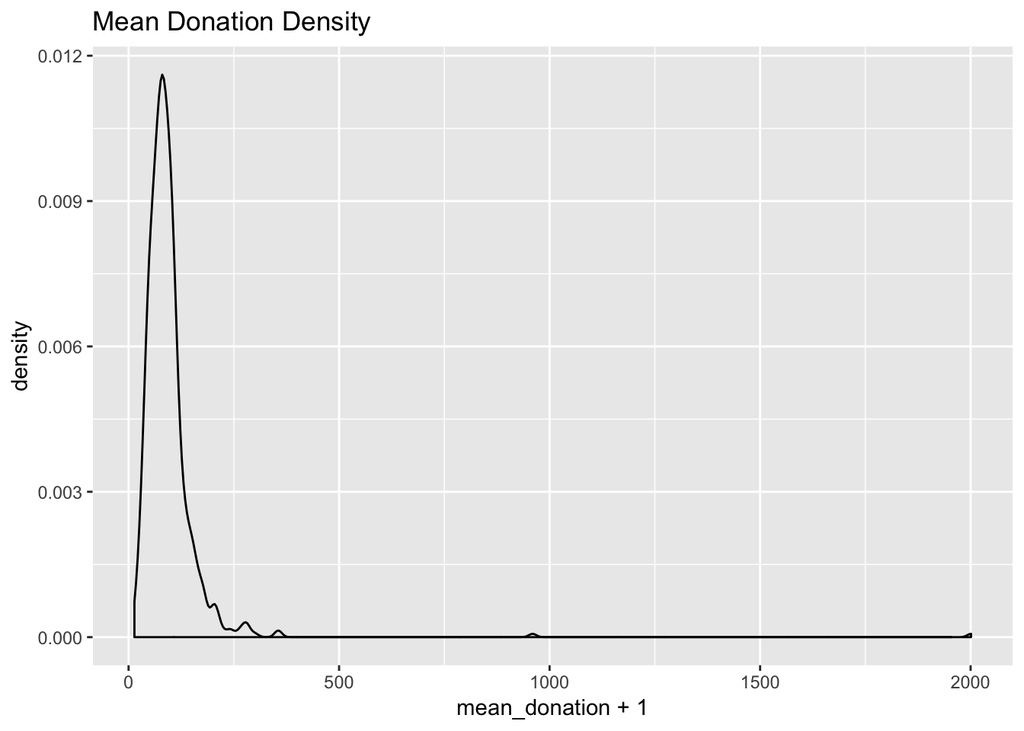

```r
dat %>%
  ggplot() + labs(title="Mean Donation Density") +
  geom_density(aes(mean_donation+1))
```

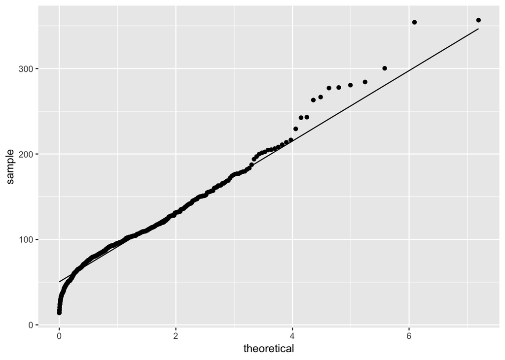

```r
dat = dat[dat$mean_donation < 500, ]

dat %>%
  ggplot() + geom_qq(aes(sample=mean_donation+1), distribution = qexp) + geom_qq_line(aes(sample=mean_donation+1), distribution = qexp)
```

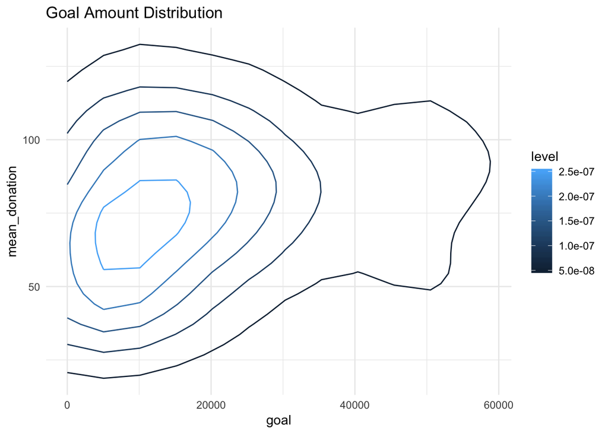

```r
dat %>%
  ggplot(aes(goal, mean_donation)) + labs(title="Goal Amount Distribution") +
  geom_density2d(aes(color=..level..)) +
  theme_minimal()
```

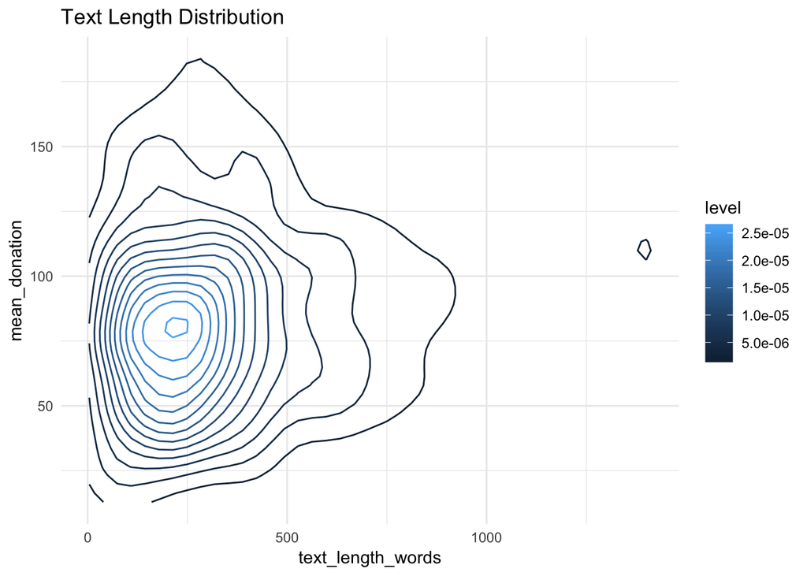

```r
dat %>%
  ggplot(aes(text_length_words, mean_donation)) + labs(title="Text Length Distribution") +
  geom_density2d(aes(color=..level..)) +
  theme_minimal()
```

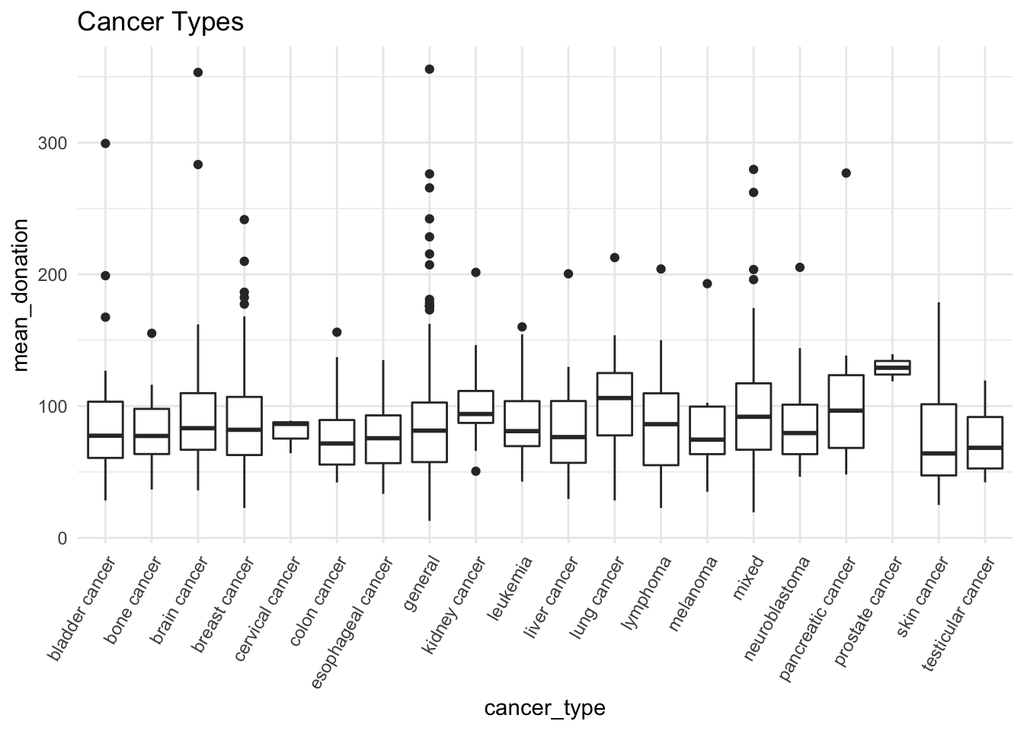

```r
dat %>%
  ggplot(aes(cancer_type, mean_donation)) + labs(title="Cancer Types") +
  geom_boxplot() +
  theme_minimal() +
  theme(axis.text.x=element_text(angle = 60, hjust=1))
```

```r
library(car)
```

- https://stats.stackexchange.com/questions/142013/correct-glmer-distribution-family-and-link-for-a-continuous-zero-inflated-data-s

The data fit an exponential fairly well, so we model with Gamma and a log link (see above answer for reason).

## Model mean donation

```r
# no fixed effects, only random
mod.none = glmer(mean_donation+1 ~ (1|year), data = dat, family = Gamma(link = "log"))
```

```
## singular fit
```

```r
# add duration category
mod.dur = glmer(mean_donation+1 ~ duration_cat + (1|year), data = dat, family = Gamma(link = "log"))
```

```
## singular fit
```

```r
# add length of text (in words)
mod.dur.length = glmer(mean_donation+1 ~ text_length_words_sc + duration_cat + (1|year), data = dat, family = Gamma(link = "log"))
```

```
## singular fit
```

```r
# add scaled goal amount
mod.dur.length.goal = glmer(mean_donation+1 ~ goal_sc + text_length_words_sc + duration_cat + (1|year), data = dat, family = Gamma(link = "log"))
```

```
## singular fit
```

```r
# add first instantiation
mod.dur.length.goal.inst = glmer(mean_donation+1 ~ inst + goal_sc + text_length_words_sc + duration_cat + (1|year), data = dat, family = Gamma(link = "log"))
```

```
## singular fit
```

```r
anova(mod.none, mod.dur, test='Chisq')
```

```
## Data: dat
## Models:
## mod.none: mean_donation + 1 ~ (1 | year)
## mod.dur: mean_donation + 1 ~ duration_cat + (1 | year)
##          Df    AIC    BIC  logLik deviance  Chisq Chi Df Pr(>Chisq)
## mod.none  3 6753.6 6767.1 -3373.8   6747.6
## mod.dur   8 6761.7 6797.7 -3372.9   6745.7 1.8628      5     0.8678
```

```r
anova(mod.dur, mod.dur.length, test='Chisq')
```

```
## Data: dat
## Models:
## mod.dur: mean_donation + 1 ~ duration_cat + (1 | year)
## mod.dur.length: mean_donation + 1 ~ text_length_words_sc + duration_cat + (1 |
## mod.dur.length:     year)
##                Df    AIC    BIC  logLik deviance  Chisq Chi Df Pr(>Chisq)
## mod.dur         8 6761.7 6797.7 -3372.9   6745.7
## mod.dur.length  9 6762.2 6802.7 -3372.1   6744.2 1.5503      1     0.2131
```

```r
anova(mod.dur.length, mod.dur.length.goal, test='Chisq')
```

```
## Data: dat
## Models:
## mod.dur.length: mean_donation + 1 ~ text_length_words_sc + duration_cat + (1 |
## mod.dur.length:     year)
## mod.dur.length.goal: mean_donation + 1 ~ goal_sc + text_length_words_sc + duration_cat +
## mod.dur.length.goal:     (1 | year)
##                     Df    AIC    BIC  logLik deviance  Chisq Chi Df
## mod.dur.length       9 6762.2 6802.7 -3372.1   6744.2
## mod.dur.length.goal 10 6716.0 6761.0 -3348.0   6696.0 48.173      1
##                     Pr(>Chisq)
## mod.dur.length
## mod.dur.length.goal  3.901e-12 ***
## ---
## Signif. codes:  0 '***' 0.001 '**' 0.01 '*' 0.05 '.' 0.1 ' ' 1
```

```r
anova(mod.dur.length.goal, mod.dur.length.goal.inst, test='Chisq')
```

```
## Data: dat
## Models:
## mod.dur.length.goal: mean_donation + 1 ~ goal_sc + text_length_words_sc + duration_cat +
## mod.dur.length.goal:     (1 | year)
## mod.dur.length.goal.inst: mean_donation + 1 ~ inst + goal_sc + text_length_words_sc + duration_cat +
## mod.dur.length.goal.inst:     (1 | year)
##                          Df    AIC    BIC  logLik deviance  Chisq Chi Df
## mod.dur.length.goal      10 6716.0 6761.0 -3348.0   6696.0
## mod.dur.length.goal.inst 13 6714.4 6772.8 -3344.2   6688.4 7.6587      3
##                          Pr(>Chisq)
## mod.dur.length.goal
## mod.dur.length.goal.inst    0.05362 .
## ---
## Signif. codes:  0 '***' 0.001 '**' 0.01 '*' 0.05 '.' 0.1 ' ' 1
```

```r
summary(mod.dur.length.goal.inst)
```

```
## Generalized linear mixed model fit by maximum likelihood (Laplace
##   Approximation) [glmerMod]
##  Family: Gamma  ( log )
## Formula:
## mean_donation + 1 ~ inst + goal_sc + text_length_words_sc + duration_cat +
##     (1 | year)
##    Data: dat
##
##      AIC      BIC   logLik deviance df.resid
##   6714.4   6772.8  -3344.2   6688.4      651
##
## Scaled residuals:
##     Min      1Q  Median      3Q     Max
## -1.7450 -0.6555 -0.1598  0.3933  6.7205
##
## Random effects:
##  Groups   Name        Variance Std.Dev.
##  year     (Intercept) 0.0000   0.000
##  Residual             0.2237   0.473
## Number of obs: 664, groups:  year, 5
##
## Fixed effects:
##                       Estimate Std. Error t value Pr(>|z|)
## (Intercept)           4.535418   0.036299 124.946  < 2e-16 ***
## instnone             -0.086640   0.045163  -1.918   0.0551 .
## instsecondhalf       -0.002051   0.049568  -0.041   0.9670
## instsecondquarter     0.049050   0.061617   0.796   0.4260
## goal_sc               0.121625   0.019965   6.092 1.11e-09 ***
## text_length_words_sc -0.011469   0.019026  -0.603   0.5466
## duration_cat.L       -0.037406   0.052891  -0.707   0.4794
## duration_cat.Q        0.004528   0.047298   0.096   0.9237
## duration_cat.C       -0.030519   0.049146  -0.621   0.5346
## duration_cat^4        0.003438   0.046676   0.074   0.9413
## duration_cat^5        0.028805   0.037478   0.769   0.4421
## ---
## Signif. codes:  0 '***' 0.001 '**' 0.01 '*' 0.05 '.' 0.1 ' ' 1
##
## Correlation of Fixed Effects:
##             (Intr) instnn instscndh instscndq gol_sc txt___ drt_.L drt_.Q
## instnone    -0.773
## instscndhlf -0.678  0.541
## instscndqrt -0.548  0.439  0.391
## goal_sc     -0.063  0.128  0.012     0.005
## txt_lngth__ -0.113  0.183  0.012     0.042    -0.152
## duratn_ct.L -0.080  0.021  0.054    -0.002    -0.026 -0.050
## duratn_ct.Q  0.209 -0.049 -0.052    -0.018     0.062 -0.056  0.013
## duratn_ct.C  0.045  0.029  0.039     0.000    -0.058  0.024  0.105 -0.037
## duratn_ct^4 -0.092 -0.001 -0.031     0.033     0.027 -0.023  0.140  0.257
## duratn_ct^5  0.089  0.012 -0.017    -0.018    -0.030 -0.024 -0.096 -0.077
##             drt_.C drt_^4
## instnone
## instscndhlf
## instscndqrt
## goal_sc
## txt_lngth__
## duratn_ct.L
## duratn_ct.Q
## duratn_ct.C
## duratn_ct^4 -0.236
## duratn_ct^5  0.311 -0.136
## convergence code: 0
## singular fit
```

## Add metaphors

```r
mod.no_metaphor = glmer(mean_donation+1 ~ no_metaphor + goal_sc + text_length_words_sc + duration_cat + inst + (1|year),
                        data = dat, family = Gamma(link = "log"))
```

```
## fixed-effect model matrix is rank deficient so dropping 1 column / coefficient
```

```
## singular fit
```

```r
mod.any_metaphor = glmer(mean_donation+1 ~ any_metaphor + goal_sc + text_length_words_sc + duration_cat + inst + (1|year),
                        data = dat, family = Gamma(link = "log"))
```

```
## fixed-effect model matrix is rank deficient so dropping 1 column / coefficient
## singular fit
```

```r
mod.dom_journey = glmer(mean_donation+1 ~ dom_journey + goal_sc + text_length_words_sc + duration_cat + inst + (1|year),
                        data = dat, family = Gamma(link = "log"))
```

```
## singular fit
```

```r
mod.dom_journey.prod = glmer(mean_donation+1 ~ journey_prod + dom_journey + goal_sc + text_length_words_sc + duration_cat  + inst + (1|year),
                        data = dat, family = Gamma(link = "log"))
```

```
## singular fit
```

```r
mod.dom_battle = glmer(mean_donation+1 ~ dom_battle + goal_sc + text_length_words_sc + duration_cat + inst + (1|year),
                        data = dat, family = Gamma(link = "log"))
```

```
## singular fit
```

```r
mod.dom_battle.prod = glmer(mean_donation+1 ~ battle_prod + dom_battle + goal_sc + text_length_words_sc + duration_cat + inst + (1|year),
                        data = dat, family = Gamma(link = "log"))
```

```
## singular fit
```

```r
mod.only_journey = glmer(mean_donation+1 ~ only_journey + goal_sc + text_length_words_sc + duration_cat + inst + (1|year),
                        data = dat, family = Gamma(link = "log"))
```

```
## singular fit
```

```r
mod.only_battle = glmer(mean_donation+1 ~ only_battle + goal_sc + text_length_words_sc + duration_cat + inst + (1|year),
                        data = dat, family = Gamma(link = "log"))
```

```
## singular fit
```

```r
mod.both_metaphor = glmer(mean_donation+1 ~ both_metaphor + goal_sc + text_length_words_sc + duration_cat + inst + (1|year),
                        data = dat, family = Gamma(link = "log"))
```

```
## singular fit
```

```r
anova(mod.dur.length.goal.inst, mod.no_metaphor)
```

```
## Data: dat
## Models:
## mod.dur.length.goal.inst: mean_donation + 1 ~ inst + goal_sc + text_length_words_sc + duration_cat +
## mod.dur.length.goal.inst:     (1 | year)
## mod.no_metaphor: mean_donation + 1 ~ no_metaphor + goal_sc + text_length_words_sc +
## mod.no_metaphor:     duration_cat + inst + (1 | year)
##                          Df    AIC    BIC  logLik deviance Chisq Chi Df
## mod.dur.length.goal.inst 13 6714.4 6772.8 -3344.2   6688.4
## mod.no_metaphor          13 6714.4 6772.8 -3344.2   6688.4     0      0
##                          Pr(>Chisq)
## mod.dur.length.goal.inst
## mod.no_metaphor                   1
```

```r
anova(mod.dur.length.goal.inst, mod.any_metaphor)
```

```
## Data: dat
## Models:
## mod.dur.length.goal.inst: mean_donation + 1 ~ inst + goal_sc + text_length_words_sc + duration_cat +
## mod.dur.length.goal.inst:     (1 | year)
## mod.any_metaphor: mean_donation + 1 ~ any_metaphor + goal_sc + text_length_words_sc +
## mod.any_metaphor:     duration_cat + inst + (1 | year)
##                          Df    AIC    BIC  logLik deviance Chisq Chi Df
## mod.dur.length.goal.inst 13 6714.4 6772.8 -3344.2   6688.4
## mod.any_metaphor         13 6714.4 6772.8 -3344.2   6688.4     0      0
##                          Pr(>Chisq)
## mod.dur.length.goal.inst
## mod.any_metaphor          < 2.2e-16 ***
## ---
## Signif. codes:  0 '***' 0.001 '**' 0.01 '*' 0.05 '.' 0.1 ' ' 1
```

```r
anova(mod.dur.length.goal.inst, mod.dom_journey)
```

```
## Data: dat
## Models:
## mod.dur.length.goal.inst: mean_donation + 1 ~ inst + goal_sc + text_length_words_sc + duration_cat +
## mod.dur.length.goal.inst:     (1 | year)
## mod.dom_journey: mean_donation + 1 ~ dom_journey + goal_sc + text_length_words_sc +
## mod.dom_journey:     duration_cat + inst + (1 | year)
##                          Df    AIC    BIC  logLik deviance  Chisq Chi Df
## mod.dur.length.goal.inst 13 6714.4 6772.8 -3344.2   6688.4
## mod.dom_journey          14 6709.6 6772.6 -3340.8   6681.6 6.7586      1
##                          Pr(>Chisq)
## mod.dur.length.goal.inst
## mod.dom_journey             0.00933 **
## ---
## Signif. codes:  0 '***' 0.001 '**' 0.01 '*' 0.05 '.' 0.1 ' ' 1
```

```r
anova(mod.dom_journey, mod.dom_journey.prod)
```

```
## Data: dat
## Models:
## mod.dom_journey: mean_donation + 1 ~ dom_journey + goal_sc + text_length_words_sc +
## mod.dom_journey:     duration_cat + inst + (1 | year)
## mod.dom_journey.prod: mean_donation + 1 ~ journey_prod + dom_journey + goal_sc + text_length_words_sc +
## mod.dom_journey.prod:     duration_cat + inst + (1 | year)
##                      Df    AIC    BIC  logLik deviance Chisq Chi Df
## mod.dom_journey      14 6709.6 6772.6 -3340.8   6681.6
## mod.dom_journey.prod 15 6710.9 6778.4 -3340.4   6680.9 0.722      1
##                      Pr(>Chisq)
## mod.dom_journey
## mod.dom_journey.prod     0.3955
```

```r
anova(mod.dur.length.goal.inst, mod.dom_battle)
```

```
## Data: dat
## Models:
## mod.dur.length.goal.inst: mean_donation + 1 ~ inst + goal_sc + text_length_words_sc + duration_cat +
## mod.dur.length.goal.inst:     (1 | year)
## mod.dom_battle: mean_donation + 1 ~ dom_battle + goal_sc + text_length_words_sc +
## mod.dom_battle:     duration_cat + inst + (1 | year)
##                          Df    AIC    BIC  logLik deviance  Chisq Chi Df
## mod.dur.length.goal.inst 13 6714.4 6772.8 -3344.2   6688.4
## mod.dom_battle           14 6709.6 6772.5 -3340.8   6681.6 6.7982      1
##                          Pr(>Chisq)
## mod.dur.length.goal.inst
## mod.dom_battle             0.009125 **
## ---
## Signif. codes:  0 '***' 0.001 '**' 0.01 '*' 0.05 '.' 0.1 ' ' 1
```

```r
anova(mod.dom_battle, mod.dom_battle.prod)
```

```
## Data: dat
## Models:
## mod.dom_battle: mean_donation + 1 ~ dom_battle + goal_sc + text_length_words_sc +
## mod.dom_battle:     duration_cat + inst + (1 | year)
## mod.dom_battle.prod: mean_donation + 1 ~ battle_prod + dom_battle + goal_sc + text_length_words_sc +
## mod.dom_battle.prod:     duration_cat + inst + (1 | year)
##                     Df    AIC    BIC  logLik deviance  Chisq Chi Df
## mod.dom_battle      14 6709.6 6772.5 -3340.8   6681.6
## mod.dom_battle.prod 15 6711.4 6778.9 -3340.7   6681.4 0.1177      1
##                     Pr(>Chisq)
## mod.dom_battle
## mod.dom_battle.prod     0.7315
```

```r
anova(mod.dur.length.goal.inst, mod.only_journey)
```

```
## Data: dat
## Models:
## mod.dur.length.goal.inst: mean_donation + 1 ~ inst + goal_sc + text_length_words_sc + duration_cat +
## mod.dur.length.goal.inst:     (1 | year)
## mod.only_journey: mean_donation + 1 ~ only_journey + goal_sc + text_length_words_sc +
## mod.only_journey:     duration_cat + inst + (1 | year)
##                          Df    AIC    BIC  logLik deviance  Chisq Chi Df
## mod.dur.length.goal.inst 13 6714.4 6772.8 -3344.2   6688.4
## mod.only_journey         14 6713.4 6776.4 -3342.7   6685.4 2.9745      1
##                          Pr(>Chisq)
## mod.dur.length.goal.inst
## mod.only_journey            0.08459 .
## ---
## Signif. codes:  0 '***' 0.001 '**' 0.01 '*' 0.05 '.' 0.1 ' ' 1
```

```r
anova(mod.dur.length.goal.inst, mod.only_battle)
```

```
## Data: dat
## Models:
## mod.dur.length.goal.inst: mean_donation + 1 ~ inst + goal_sc + text_length_words_sc + duration_cat +
## mod.dur.length.goal.inst:     (1 | year)
## mod.only_battle: mean_donation + 1 ~ only_battle + goal_sc + text_length_words_sc +
## mod.only_battle:     duration_cat + inst + (1 | year)
##                          Df    AIC    BIC  logLik deviance  Chisq Chi Df
## mod.dur.length.goal.inst 13 6714.4 6772.8 -3344.2   6688.4
## mod.only_battle          14 6708.7 6771.7 -3340.4   6680.7 7.6506      1
##                          Pr(>Chisq)
## mod.dur.length.goal.inst
## mod.only_battle            0.005675 **
## ---
## Signif. codes:  0 '***' 0.001 '**' 0.01 '*' 0.05 '.' 0.1 ' ' 1
```

```r
anova(mod.dur.length.goal.inst, mod.both_metaphor)
```

```
## Data: dat
## Models:
## mod.dur.length.goal.inst: mean_donation + 1 ~ inst + goal_sc + text_length_words_sc + duration_cat +
## mod.dur.length.goal.inst:     (1 | year)
## mod.both_metaphor: mean_donation + 1 ~ both_metaphor + goal_sc + text_length_words_sc +
## mod.both_metaphor:     duration_cat + inst + (1 | year)
##                          Df    AIC    BIC  logLik deviance  Chisq Chi Df
## mod.dur.length.goal.inst 13 6714.4 6772.8 -3344.2   6688.4
## mod.both_metaphor        14 6712.5 6775.4 -3342.2   6684.5 3.8988      1
##                          Pr(>Chisq)
## mod.dur.length.goal.inst
## mod.both_metaphor           0.04832 *
## ---
## Signif. codes:  0 '***' 0.001 '**' 0.01 '*' 0.05 '.' 0.1 ' ' 1
```